# SAEIV : SAI

Le SAI (Système d’Aide à l’Information) est un sous-système du SAEIV.

## Présentation

Le Système d’Aide à l’Exploitation (SAE) désigne globalement un SAE Temps Différé (SAE-TD) et le Système d’Aide à l’Information (SAI) un SAE Temps réel (SAE-TR). Ce sont des systèmes informatiques implantés au Poste de Commande Centralisé (PCC), en liaison avec les Systèmes d’Informations Voyageurs (SIV-BERRY) des bus.

Le SAE assiste les opérateurs du PCC (exploitants) dans ses principales missions d’exploitation du réseau de bus. Les fonctionnalités principales du SAE sont l’élaboration du référentiel et le transfert des données du référentiel.

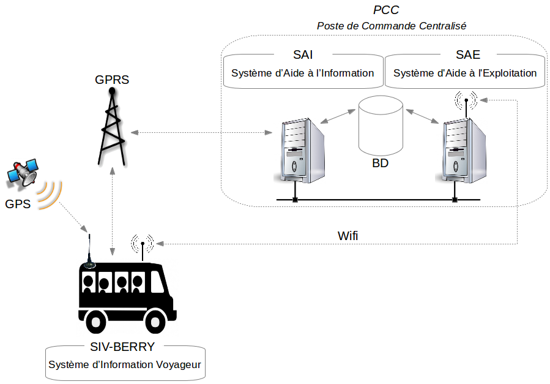

Le référentiel est un ensemble de données descriptives de l’exploitation du réseau (référentiel SAE). Ces données concernent :

- la description de la topologie du réseau : lignes, arrêts, chaînages des tronçons, etc.
- la description des horaires : calendriers, services matériels etc.
- la description des ressources : conducteurs, véhicules etc.

Ces données sont mémorisées dans la BD (base de données) du PCC, et mises à disposition des différents sous-systèmes en fonction de leurs besoins.

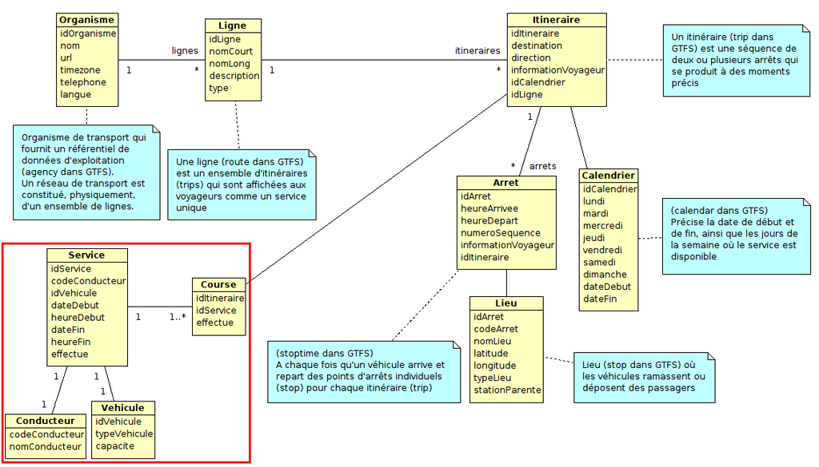

Le SAE (SAE-TD) assure la fonction de transfert des données du référentiel :

- vers le SAI (SAE-TR) : données nécessaires à la journée d’exploitation suivantes transférées par réseau au SAE-TR (automatiquement ou manuellement) chaque jour avant l’heure de début d’exploitation ;
- vers les SIV-BERRY de chaque bus : données descriptives de la topologie et des horaires de la journée, préparées et transférées par Wifi (automatiquement ou manuellement) tous les soirs.

## Manuel d’installation du SAI

1. Exécuter le programme d’installation setup-sai.sh

```
$ sudo ./setup-sai.sh
```

2. Paramétrer l’application

L’application gère ses paramètres de configuration à partir d’un fichier `sai.ini` :

```
[sai]
;adresse="127.0.0.1"
;port=64465
port=5000

[periode]
; en millisecondes
ihm=1000
communication=1000

[referentiel]
; si vide le dossier sera referentiel/
dossier="/usr/share/sai/referentiel"
nom="referentiel-sai.sqlite"

[images]
; si vide le dossier sera images/
dossier="/usr/share/sai/images"

[carte]
;Toulouse
latitude=1.445
longitude=43.605
zoom=13
largeur=750
hauteur=500
```

3. Démarrer le SAI

```
$ sai
```

## Manuel d’utilisation du SAI

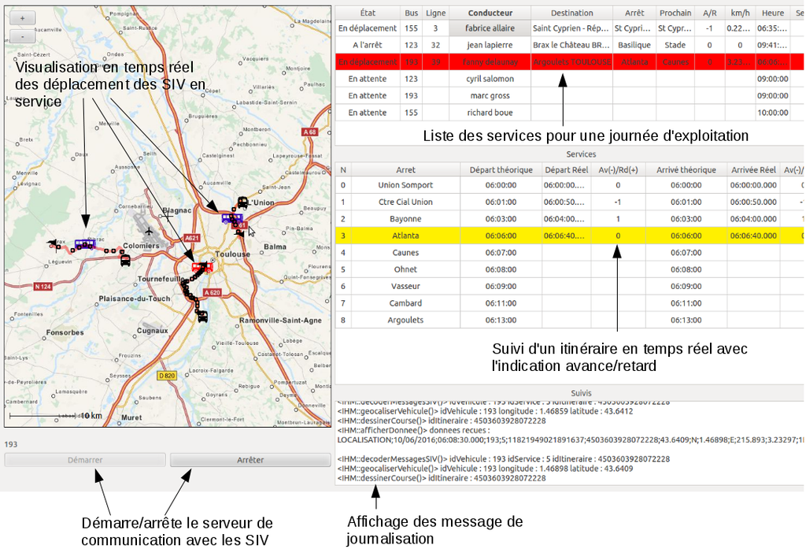

*Remarque :* Le SAI ne charge que les services pour le jour courant.

## Glossaire

- SAE (Système d’Aide à l’Exploitation) : il assiste les opérateurs du PCC (exploitants) dans ses principales missions d’exploitation du réseau de bus. Les fonctionnalités principales du SAE sont l’élaboration du référentiel et le transfert des données du référentiel.
- SAI (Système d’Aide à l’Information) : il assiste le régulateur pour qu’il puisse suivre sur un écran la position des bus sur le réseau, ligne par ligne et prendre des décisions de contrôle de trafic. Il pourra ainsi visualiser l’avance ou le retard des bus.
- SIV (Système d’Informations Voyageurs) : c’est une installation présente dans le véhicule de transport en commun permettant, de manière automatique, d’informer les voyageurs visuellement et par un dispositif sonore à propos du trajet (arrivée à un arrêt, liste des arrêts, destination …).
- PCC (Poste de Commande Centralisé) : il regroupe le SAE, SAI et la base de données contenant le référentiel du réseau de transport.
- Référentiel : c’est un ensemble de données descriptives de l’exploitation du réseau : topologie du réseau (lignes, arrêts, chaînages des tronçons, etc.), description des horaires (calendriers, services matériels etc.) et description des ressources (conducteurs, véhicules etc.). Ces données sont mémorisées dans la BD (base de données) du PCC, et mises à disposition des différents sous-systèmes en fonction de leurs besoins.

Retour au sommaire